# Data Visualization Project

Author

Ronald Auguste

Published

October 10, 2026

# Story Summary

In Trinidad & Tobago, as elsewhere in Latin America and the Caribbean, Attention-Deficit/Hyperactivity Disorder (ADHD) is thought to be widely undiagnosed and undertreated, placing affected children at risk of negative outcomes. Although the literature identifies this regional phenomenon as problematic, its underlying dynamics remain unclear. Our previous study examined factors that may contribute to undiagnosed and undertreated ADHD in Trinidad & Tobago. Compared with Canadians, Trinidadian and Tobagonian parents and teachers were more likely to attribute ADHD-related behaviours to indiscipline or low motivation. They also demonstrated markedly less ADHD-specific knowledge. However, Canada is considered highly receptive to biomedical interpretations of children’s atypical behaviours. Consequently, our initial comparison could not establish whether ADHD-specific knowledge in Trinidad & Tobago was low in a broad sense, or merely lower than in a highly medicalized country. The current study addresses this limitation by comparing ADHD-specific knowledge among Trinidadian and Tobagonian parents and teachers with knowledge reported in other countries. To make this comparison, we combined our data with comparable data collected by researchers at RMIT University. Preliminary findings indicate that Trinidad and Tobago had the lowest parent and teacher knowledge scores among all sampled countries. Further inferential analyses will determine whether these differences are statistically significant.

# Version A: Scientific Article

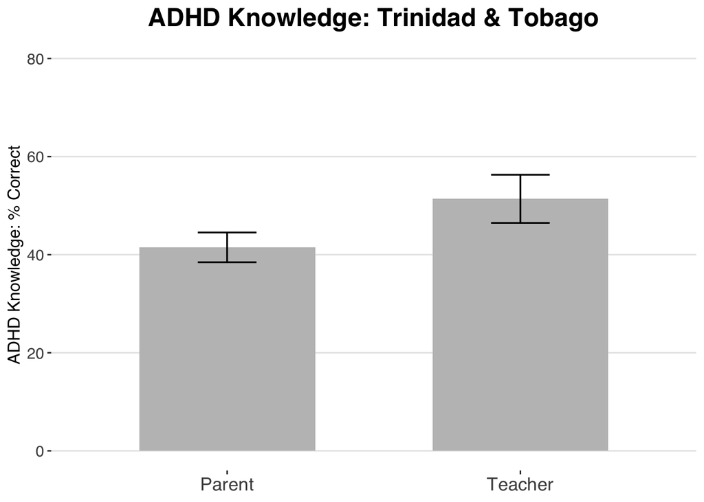

Figure 1: ADHD knowledge among parents and teachers in Trinidad & Tobago. *Note.* Bars show mean percentage correct on the ADHD Knowledge Questionnaire. Error bars represent 95% confidence intervals.

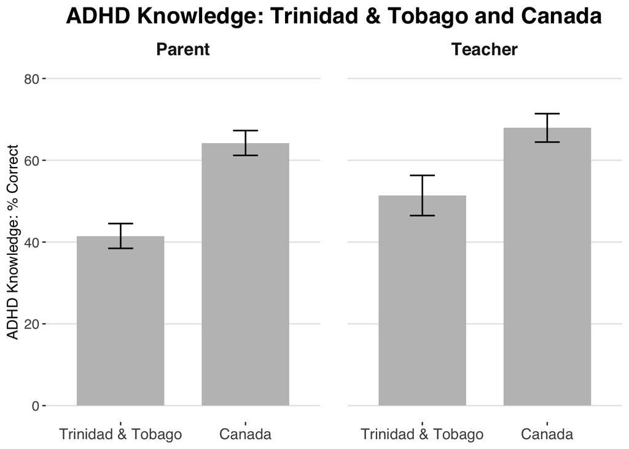

Figure 2: ADHD knowledge among parents and teachers in Trinidad & Tobago and Canada. *Note.* Canadian data are from the original sample only. Error bars represent 95% confidence intervals.

It is appealing to infer that ADHD in Trinidad & Tobago goes undiagnosed beacuse its symptoms go unrecognized, itself a product of low knowldege. while appealing, these causal inferences are tenuous for multiple reasons, one of which relates to “low knowledge”. Our results indicate that Trinidad & Tobago’s ADHD knowledge was *lower* than Canada’s, but this contrast may be misleading. Especially in terms of ADHD, Canada is thought to be a highly medicalized society, fluent and au courant with biomedical interpretations of atypical behaviours in children. It is therefore unclear whether ADHD knowledge in Trinidad & Tobago is *particularly* low, or only appears as such in contrast to Canada. As such, the present study is geared toward contextualizing ADHD knowledge in Trinidad & Tobago, against the backdrop of a broader cross-section of countries.

# Methods

## Data

**Table 1**

*Sample size by country and role*

| Country | Participants Parents | Participants Teachers | Participants Total |
| --- | --- | --- | --- |
| Trinidad & Tobago | 127 | 47 | 174 |
| India | 30 | – | 30 |
| France | 37 | – | 37 |
| Spain | 33 | 20 | 53 |
| Poland | 37 | – | 37 |
| Portugal | 26 | – | 26 |
| South Africa | – | 69 | 69 |
| Mexico | 34 | 20 | 54 |
| Kenya | 24 | – | 24 |
| Brazil | 23 | – | 23 |
| Canada | 111 | 94 | 205 |
| Australia | 37 | 105 | 142 |
| U.S. | 72 | 82 | 154 |
| U.K. | 22 | 92 | 114 |
| Total | 613 | 529 | 1,142 |

Note. Countries are ordered by overall mean ADHD knowledge score (lowest to highest). Dashes indicate no participants in that role.

## Instrument and Analysis

All participants completed the ADHD Knowledge Questionnaire (AKQ), developed by Kos et al. (2004). The version used in our original study was adopted from Youssef et al. (2015) and comprised 26 items (True/False, “I don’t know”). The RMIT version comprised the original 27 items. The only substantive difference between the two versions was item 26 from the original (“Research has shown that prolonged use of stimulant medications leads to increased addiction (i.e., drug, alcohol) in adulthood”). For the present study, we computed the percentage of correct responses on the 26 items common to both prior analyses. Missing items were not imputed. All current analyses were conducted in R, version 4.6.0, using the following packages: `tidyverse`, `psych`, `patchwork`, `janitor`, `ggthemes` and `gt`.

# Results

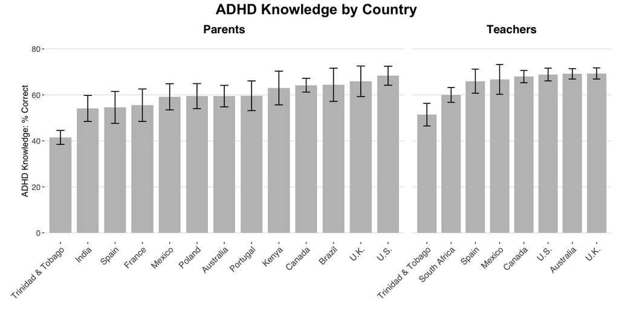

Figure 3: ADHD knowledge among parents and teachers by country. *Note.* Countries are ordered by mean score within each role. Error bars represent 95% confidence intervals.

As seen in Figure 3, mean ADHD knowledge in Trinidad & Tobago was the lowest among all countries sampled, for both parents (*M* = 41.49) and teachers (*M* = 51.39).

# Conclusion

Initial descriptive statistics suggest that factual knowledge about ADHD in Trinidad & Tobago is low in comparison with a broader cross-section of countries. Further inferential tests will be conducted to determine whether preliminary findings are statistically significant.

# Accessible/Dynamic Outlet Version

In Trinidad & Tobago, children with ADHD can often end up without the supports they need, because their parents and teachers don’t recognize their symptoms.

If the adults in their lives don’t know about ADHD, they won’t be able to recognize children’s symptoms.

Right now, it isn’t clear how much parents and teachers in Trinidad & Tobago know about ADHD. That’s why we decided to measure it.

We asked 174 parents and teachers 26 questions about ADHD. Here’s how they performed on average:

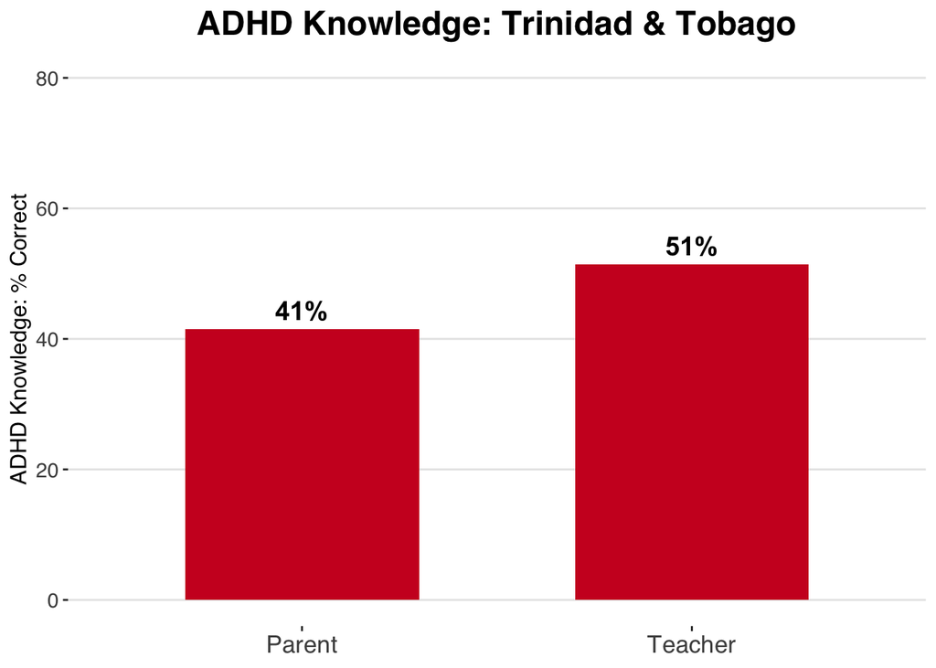

41.49% accuracy for parents and 51.39% accuracy for teachers seems low. But…..is it *abnormally* low, or do other countries look similar?

To get some context, we measured ADHD knowledge in Canada as well. When we compared both countries, here’s what we found:

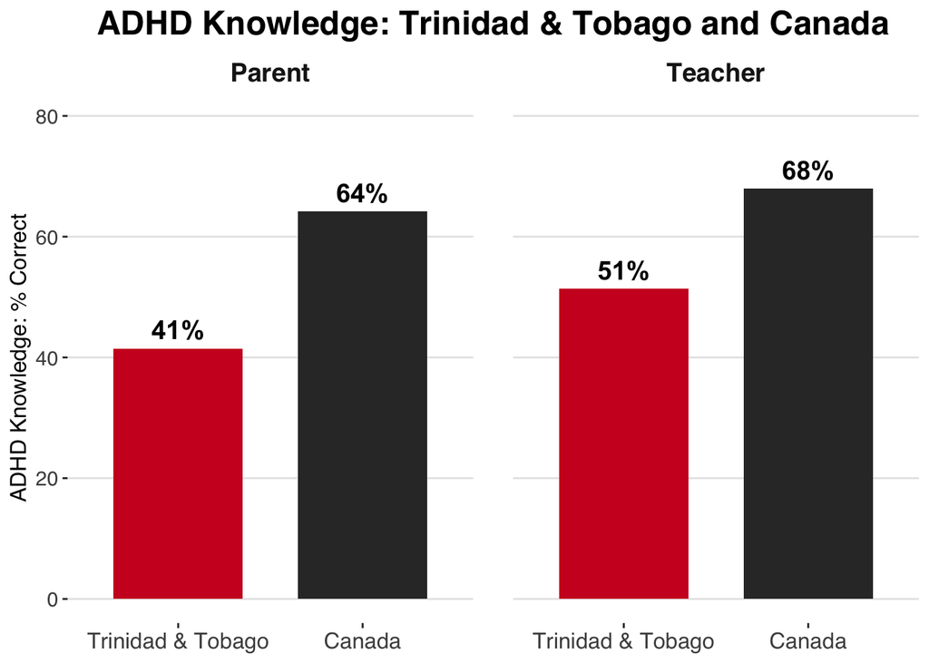

In a head-to-head comparison with Canada, ADHD knowledge in Trinidad & Tobago really does seem low!

*BUT……*

Maybe Canada’s ADHD knowledge is *abnormally high* (instead of Trinidad & Tobago’s being *abnormally low*)??

Fair question, especially since Canada’s known for how much it’s parents and teachers recognize children’s ADHD symptoms.

…….

*WE NEED MORE DATA!!*

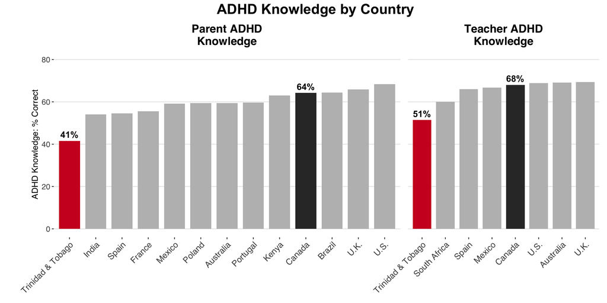

It was lower than all the additional countries for both parents and teachers.

While this might seem discouraging, there are two important things to consider:

**1:** These results are *preliminary*

**2:** We can use these insights to develop Trinidad & Tobago-specific ADHD awareness campaigns that focus on the *exact things* that parents and teachers aren’t aware of!